# Precios Inmobiliarios en Santa Cruzde la Sierra

Giovanny Lopez

04 de Septiembre de 2020

# **LIMPIEZA DE DATOS EN R**

## Carga de Datos

```r
library(tidyverse)
casas <- read_csv("https://raw.githubusercontent.com/giovannylopezd/Web-Scrapping/master/casas.csv")
```

Echamos un vistazo a la tabla y vemos la cantidad de observaciones

```r
casas
```

| titulo | tipo | dormitorios | baños | garajes | m2 | zona | precio |
| --- | --- | --- | --- | --- | --- | --- | --- |
| Casa En Venta Condominio Valle Del Cartago / Km 8 Norte | Casas | 3 | 2 | 2 | 272 | Norte | 156.000 |
| Casa En Venta En El Urubo - Cond. Rio Sierra | Casas | 4 | 3 | 3 | 721 | Urubó | 398.000 |
| Casa En Venta Sobre Avenida Con Local Comercial | Casas | 4 | 2 | 2 | 300 | Sur | 95.000 |
| Casa En Venta En Colinas Del Urubo Sector 1 La Cañada | Casas | 5 | 3 | 3 | 475 | Oeste | 499.000 |
| Hermosa Casa Quinta Zona Urubo Trejo | Casas | 4 | 3 | 0 | 330 | Urubó | 300.000 |
| NA | NA | NA | NA | 0 | NA | NA | NA |
| Casa En Venta En El Condominio La Pradera, Zona Norte De Santa Cruz | Casas | 4 | 3 | 3 | 317 | Norte / Remanso | 220.000 |
| Casa De Lujo En Venta !!! | Casas | 5 | 3 | 3 | 382 | Norte | 355.000 |
| En Equipetrol - Amplia Casa De 4 Dormts Ideal Para Inversion | Casas | 4 | 3 | 2 | 260 | Norte / Equipetrol | 279.000 |
| Alquiler Casa Grande Comercial Zona Céntrica C/opción A Venta | Casas | 5 | 3 | 3 | 630 | Centro | 600.000 |

[output cut: 887 more lines]

## Eliminación de NA’s

```r
# filtramos valores vacíos según la variable precio
casas <- casas %>% filter(!is.na(precio))
# Observamos que precio tiene una clase que no nos sirve para modelar
class(casas$precio)
```

```
## [1] "character"
```

## Formato de Precio

Aquí quitamos los puntos de los números

```r
# Creamos una función que elimine los puntos
reemplazar = function(x)setNames("",".")[x]
# Aplicamos la función para reemplazar los puntos
casas$precio <- stringr::str_replace_all(as.character(casas$precio), "[.]", reemplazar)
# Observamos los datos
head(casas$precio,24)
```

```
##  [1] "156000"    "398000"    "95000"     "499000"    "300000"    "220000"
##  [7] "355000"    "279000"    "600000"    "393000"    "Consultar" "305000"
## [13] "185000"    "1100000"   "180000"    "395000"    "250000"    "460000"
## [19] "652869"    "118000"    "690000"    "349000"    "108000"    "275000"
```

Aquí podemos dar el formato numérico a los valores y eliminamos los NA’s.  
1. Removemos los NA’s debido a la presencia de la palabra “Consultar”.  
2. Removemos los precios menores a USD 10.000.  
3. Contamos las filas resultantes

```r
# Convertimos a formato numérico
options(scipen = 999)
casas$precio <- as.numeric(casas$precio)
casas <- casas %>% filter(!is.na(precio) & precio > 10000)
paste('Quedan',nrow(casas),'observaciones en nuestra tabla de datos.')
```

```
## [1] "Quedan 879 observaciones en nuestra tabla de datos."
```

## Visualización de Distribuciones

Conocer la distribución de la variable a predecir es un importante para determinar qué tipo de métodos se utilizarán en la fase de modelación de los datos.  
Para esto se puede realizar una exploración visual con el fin de seleccionar solo las observaciones representativas y coherentes.

Revisamos la relación entre **precio** y **m2**, luego vamos filtrando hasta encontrar un punto visual donde pueda encontrarse alguna relación.

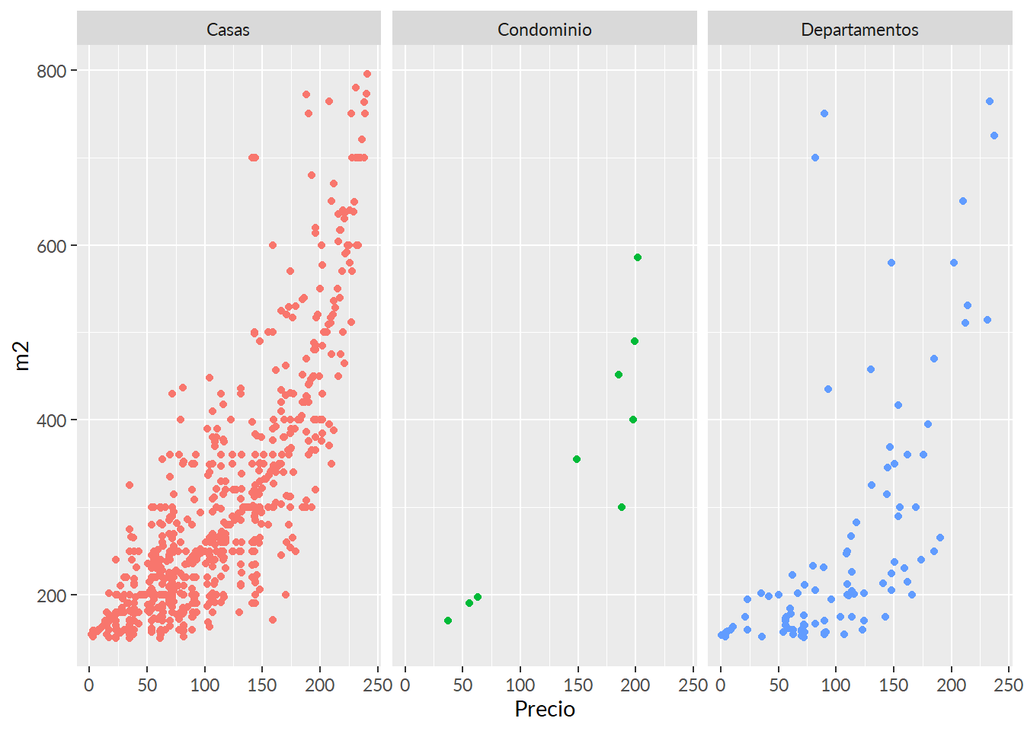

```r
library(extrafont)
casas %>%
    filter(m2 < 800 & m2 > 100) %>%  # Usualmente queremos inmuebles dentro de estos parámetros de superficie construida
    ggplot(aes(as.numeric(reorder(precio,m2)), m2, color = tipo)) +
    geom_point() +
    facet_wrap(~tipo) +
    theme(legend.position = "none",
         text = element_text(size = 11, family = "Lato")) +
    labs(x = "Precio", y = "m2")
```

Veamos la distribución del precio mediante un histograma considerando que hay mejores resultados con los filtros anteriores, además de quitar la categoría **Condominios** que aporta poco al modelo y tomar en cuenta solo precios menores a **1 millón de dólares**

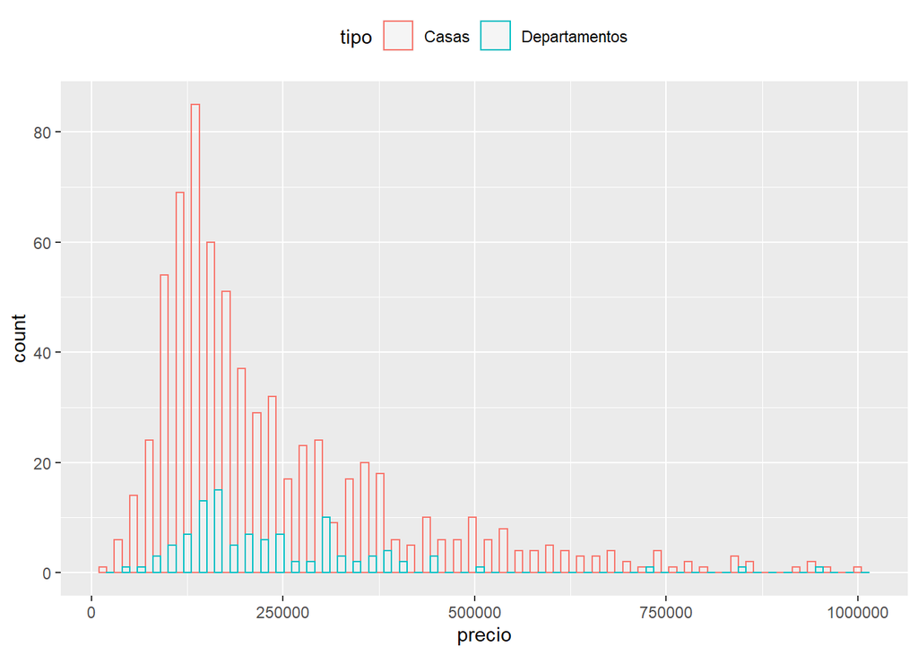

```r
casas %>%
  filter(tipo != "Condominio", precio <= 1000000, m2 < 800 & m2 > 100) %>%
  ggplot(aes(precio, color = tipo)) +
  geom_histogram(bins = 50, fill = "white", position="dodge", alpha = 0.2)+
  theme(legend.position="top")
```

La distribución en el histograma anterior parece indicar que existen pocas propiedades con precios de venta mayores a **500000 dólares**. Para poder evaluar mejor la distribución del precio de venta veamos si una gráfica de cajas puede aportar algo más intuitivo a nuestra limpieza.

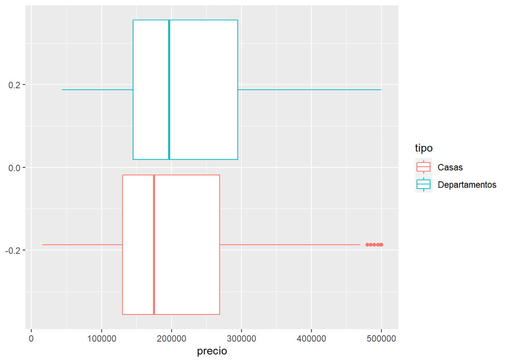

```r
casas %>%
  filter(tipo != "Condominio", precio <= 500000, m2 < 800 & m2 > 100) %>%
  ggplot(aes(precio, color = tipo)) +
  geom_boxplot()
```

Como conclusión sobre el análisis de distribución de los datos, podemos filtrar las observaciones para tener valores donde:  
1. El precio sea menor a **500 000 dólares** y mayor a **50 000 dólares.** 2. La superficie construida sea menor a **800 m2** y mayor a **100 m2.** 3. El tipo de propiedad se limite solamente a **Casas** y **Departamentos**

```r
casas <- casas %>% filter(precio < 500000 & precio > 50000,
                          m2 < 800 & m2 > 100,
                          tipo != "Condominio")
```

```r
paste('Quedan',nrow(casas),'observaciones en nuestra tabla de datos.')
```

```
## [1] "Quedan 722 observaciones en nuestra tabla de datos."
```

El resultado de nuestra selección de observaciones representativas se muestra en la siguiente gráfica de puntos entre **m2** (*la predictora que puede aportar más para este caso*) y **precio** donde claramente se pueden localizar algunos valores atípicos que según la cantidad total de datos pueden corregirse, eliminarse o simplemente mantenerlas asumiendo que no hay suficientes atípicos para afectar la precisión del modelo.

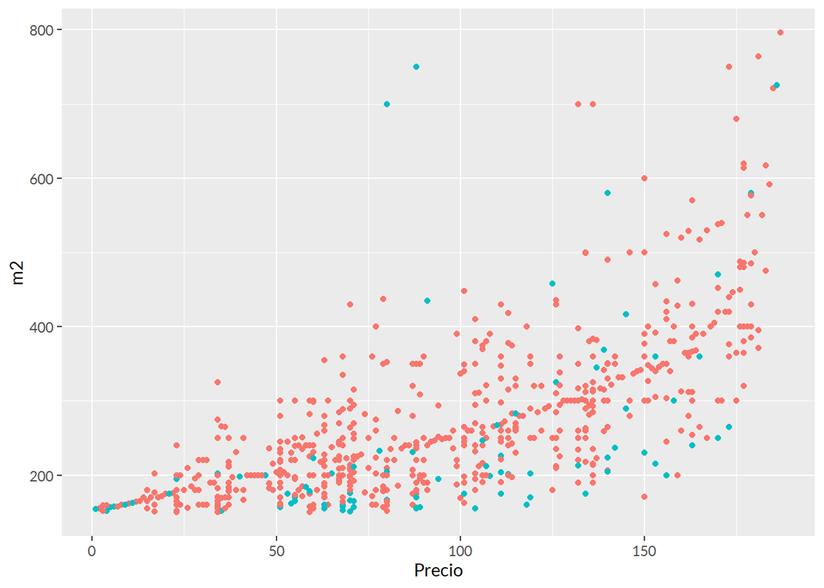

```r
casas %>%
ggplot(aes(as.numeric(reorder(precio,m2)), m2, color = tipo)) +
    geom_point() +
    theme(legend.position = "none",
         text = element_text(size = 11, family = "Lato")) +
    labs(x = "Precio", y = "m2")
```

## Atípicos

**Nota:** *Los valores atípicos no suelen ser muchos y, por lo tanto, no llegan a afectar tanto a un modelo con variables normalizadas o estandarizadas así que, si se desea, se puede omitir esta sección*

### Ubicación de Atípicos

Para este caso, solo eliminaremos los **Departamentos** alejados de la tendencia ubicados por encima de **700 m2**

```r
casas %>% filter(m2 >= 700, tipo == "Departamentos")
```

| titulo | tipo | dormitorios | baños | garajes | m2 | zona | precio |
| --- | --- | --- | --- | --- | --- | --- | --- |
| Hermoso Departamento En Condominio Mirage | Departamentos | 1 | 1 | 0 | 750 | Centro | 145000 |
| Condominio Taruma Tower Credito Directo 2 Dormitorio | Departamentos | 2 | 2 | 1 | 725 | Norte | 79750 |
| Vendo Lindo Dpto 3er Anillo Banzer | Departamentos | 3 | 3 | 1 | 700 | Norte | 110000 |

### Eliminación de Atípicos

Con los atípicos ubicados, solo ingresamos los datos y removemos estas filas de la tabla

```r
# Para asegurarnos de que el código está correcto hacemos algunas verificaciones
antes = nrow(casas)
casas <- casas[!(casas$precio == 110000 & casas$m2 == 700),]
casas <- casas[!(casas$precio == 79750 & casas$m2 == 725),]
casas <- casas[!(casas$precio == 145000 & casas$m2 == 750),]
despues = nrow(casas)
filas_eliminadas = antes-despues
paste("Se eliminaron", filas_eliminadas, "filas")
```

```
## [1] "Se eliminaron 3 filas"
```

### Demostración de Reemplazo de valores

A manera didáctica podemos observar, gracias a una búsqueda rápida en la web, el caso donde una de las propiedades presenta un valor erróneo, se trata del siguiente caso:  
- **Casa** de **USD 385000** con **750 m2** con un valor real **450 m2**

```r
# Proceso para reemplazar valores dadas ciertas condiciones lógicas
casas$m2[casas$m2 == 750 & casas$precio == 385000] <- 450
```

## Limpieza de Zonas

Comencemos dando un vistazo a cómo lucen los datos luego de la limpieza de Precio y la superficie construida (m2)

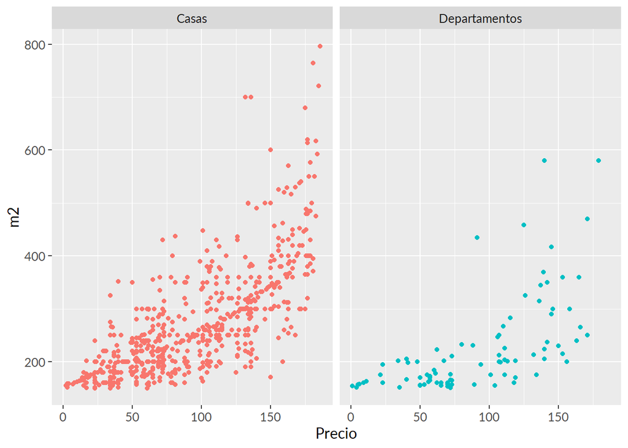

```r
casas %>%
    ggplot(aes(as.numeric(reorder(precio,m2)), m2, color = tipo)) +
    geom_point() +
    facet_wrap(~tipo, ncol = 2) +
    theme(legend.position = "none",
          text = element_text(size = 12, family = "Lato")) +
    labs(x = "Precio", y = "m2")
```

```r
paste('Quedan',nrow(casas),'observaciones en nuestra tabla de datos.')
```

```
## [1] "Quedan 719 observaciones en nuestra tabla de datos."
```

### Distribución de las zonas

Ahora es momento de explorar un poco más sobre las zonas.  
Vemos que se distinguen claramente 6 zonas de la Ciudad de Santa Cruz así como algunas variaciones.

```r
casas %>% count(zona, sort = T)
```

| zona | n |
| --- | --- |
| Norte | 229 |
| Sur | 95 |
| Oeste | 78 |
| Este | 70 |
| Norte / Remanso | 63 |
| Urubó | 54 |
| Centro | 50 |
| Norte / Equipetrol | 29 |
| Oeste / Las palmas | 12 |
| Norte / Hamacas | 11 |

[output cut: 5 more lines]

### Corrección de NA’s

Una de las variaciones es un *NA* que, con una búsqueda rápida en la web, se puede deducir su zona y espacio de garajes. Es así que rellenamos la información del NA sabiendo que tiene 2 garajes disponibles y es de zona Norte / Equipertol.

```r
casas$zona[is.na(casas$zona)] <- "Norte"
casas$garajes[casas$garajes == 0 & casas$precio == 374000] <- 2
```

### Reubicación de Zonas

Ahora necesitamos conocer las zonas de los 3 inmuebles ubicados en *Ciudadelas*.  
Nuevamente, buscando en la web, encontramos que:  
- La Casa de USD 75000 es de **zona Este**  
- La Casa de USD 135000 es de **zona Norte** y con 2 garajes  
- El Departamento de USD 95000 es de **zona Oeste** y con 123 m2

```r
casas %>% filter(zona == "Ciudadelas")
```

| titulo | tipo | dormitorios | baños | garajes | m2 | zona | precio |
| --- | --- | --- | --- | --- | --- | --- | --- |
| Hermosa Casa En Venta De 2 Planta | Casas | 3 | 3 | 0 | 162 | Ciudadelas | 135000 |
| Vendo Casa De Ocasión Serca A La Plaza Del Mechero | Casas | 3 | 2 | 1 | 180 | Ciudadelas | 75000 |
| Zona Oeste Entre 3er Y 4to Anillo Av. Centenario | Departamentos | 3 | 3 | 1 | 223 | Ciudadelas | 95000 |

### Corrección de Zonas

Con los datos recabados, reemplazamos los valores de la siguiente manera:

```r
casas$zona[casas$zona == "Ciudadelas" & casas$precio == 75000] <- "Este"
casas$zona[casas$zona == "Ciudadelas" & casas$precio == 135000] <- "Norte"
casas$garajes[casas$titulo == "Hermosa Casa En Venta De 2 Planta"] <- 2
casas$zona[casas$zona == "Ciudadelas" & casas$precio == 95000] <- "Oeste"
casas$m2[casas$titulo == "Zona Oeste Entre 3er Y 4to Anillo Av. Centenario"] <- 123
```

### Limpieza de Zonas

Ahora ya podemos diferenciar 6 zonas que abarcan la gran mayoría del territorio cruceño  
así como las variaciones que deberían concatenarse según la zona:

1. Centro
2. Este
3. Norte == Equipetrol | Hamacas | Remanso
4. Oeste == Doble via la guardia | Las palmas | Urbari
5. Sur == Polanco
6. Urubó

**Nota:** *Para no tener mayores problemas con el codificado de palabras eliminamos la tilde en la palabra “**Urubó**” y “**baños**” por “**duchas**”*

```r
casas$zona[casas$zona == "Norte / Equipetrol"] <- "Norte"
casas$zona[casas$zona == "Norte / Hamacas"] <- "Norte"
casas$zona[casas$zona == "Norte / Remanso"] <- "Norte"
casas$zona[casas$zona == "Oeste / Doble via la guardia"] <- "Oeste"
casas$zona[casas$zona == "Oeste / Las palmas"] <- "Oeste"
casas$zona[casas$zona == "Oeste / Urbari"] <- "Oeste"
casas$zona[casas$zona == "Sur / Polanco"] <- "Sur"
# Eliminamos la tilde
casas$zona[casas$zona == "Urubó"] <- "Urubo"
# Cambiamos le nombre de baños por duchas
names(casas)[4] <- "duchas"
```

## Distribución de Propiedades

Ahora podemos ver cómo luce la distribución de las zonas

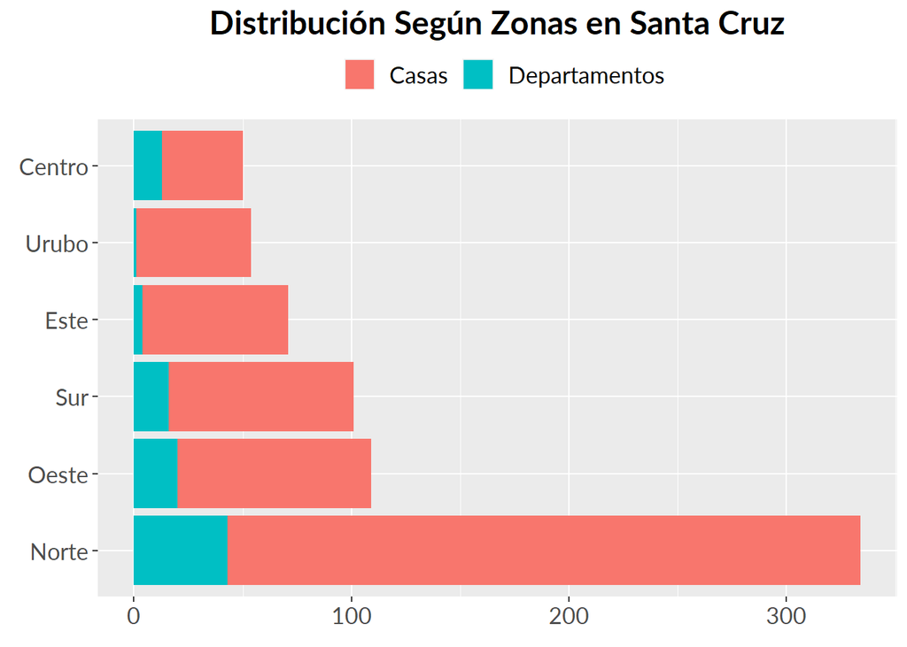

```r
casas %>%
  count(zona, tipo, sort = T) %>%
  ggplot(aes(reorder(zona,-n))) +
  geom_col(aes(y = n, fill = tipo)) +
  coord_flip() +
  theme(
    legend.box      = "horizontal",
    legend.title    = element_blank(),
    legend.position = "top",
    plot.title = element_text(face = "bold", size = (18), hjust = 0.5),
    text = element_text(size = 16, family = "Lato")
    ) +
  labs(title = "Distribución Según Zonas en Santa Cruz",
       x = element_blank(), y = element_blank())
```

## Ordenamiento de variables

Por último, podemos ver el resultado final de los datos que hemos limpiado

```r
casas <- casas %>% select(tipo,zona,dormitorios,duchas,garajes,m2,precio)
str(casas)
```

```
## tibble [719 x 7] (S3: tbl_df/tbl/data.frame)
##  $ tipo       : chr [1:719] "Casas" "Casas" "Casas" "Casas" ...
##  $ zona       : chr [1:719] "Norte" "Urubo" "Sur" "Oeste" ...
##  $ dormitorios: num [1:719] 3 4 4 5 4 4 5 4 3 4 ...
##  $ duchas     : num [1:719] 2 3 2 3 3 3 3 3 3 3 ...
##  $ garajes    : num [1:719] 2 3 2 3 0 3 3 2 3 1 ...
##  $ m2         : num [1:719] 272 721 300 475 330 317 382 260 550 176 ...
##  $ precio     : num [1:719] 156000 398000 95000 499000 300000 220000 355000 279000 393000 305000 ...
```

## Exportación de Datos

```r
write.table(casas, 'casas_limpias.csv', row.names = FALSE)
```